# Lab 06 Prelab - A review of residuals and fitting

### Estimating uncertainties in fitting parameters (fitting 2 parameters)

To estimate uncertainties in fitting parameters, we will use the method of looking at the range of reasonable best-fit lines and treating that as a confidence interval. We will make the steepest possible best-fit line "Max" (as in maximum slope) that still does a reasonable job of fitting the data and a least steep "Min" (as in minimum slope) that also does a reasonable job of fitting the data. We will call our original model line "Best". Use the "Best" parameters for the starting guesses for the "Max" and "Min" fit parameters. While doing this adjusting to find limits on the range of reasonable fits, we are adjusting both the slope and the intercept to find the steepest reasonable line. The parameter choices with the maximum reasonable slope correspond to that with the minimum reasonable intercept.

**Your turn #5:** Try adjusting the slope and intercept parameters in the plot below to find the models that correspond to the maximum and minimum slopes that still correspond to reasonable fits. Recall that you will also need to adjust the y-intercepts as well in this process.

*Note that similar to estimating confidence intervals with your individual measurements, this process involves some judgement and different people will come up with slightly different, but still reasonable, values; so do not worry if you got slightly different numbers!*

Your maximum slope answers:

- m(max) = 0.37
- b(min) = 0.13

Your minimum slope answers:

- m(min) = 0.32
- b(max) = 0.19

##### **Answer #5 Max:**

We find that $m_{\text{max}} = 0.37$ and $b_{\text{min}} = 0.13$ correspond to the maximum slope model still having a reasonable fit

##### Plots to adjust to investigate maximum and minimum slopes

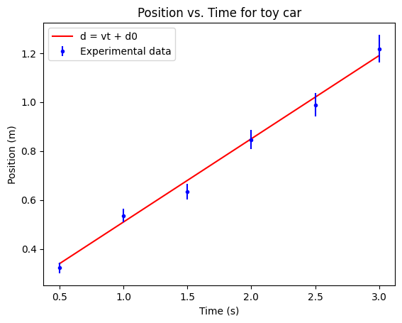

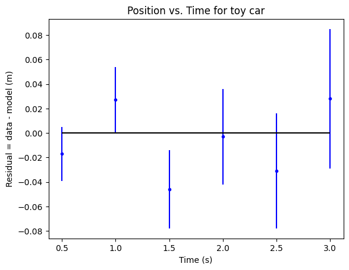

```python
# Data/Model Plot
# Step 1: find the limits of the data:
xmin = np.min(tVec) # use the np.min function to find the smallest x value
xmax = np.max(tVec) # same for max
#print (xmin, xmax)  # uncomment to see what the limits are

# Step 2: generate a bunch of x points between xmin and xmax
xpoints = np.linspace(xmin, xmax, 200) # gives 200 evenly spaced points between xmin and xmax
#print(xpoints) # uncomment to see the x values that were generated.

# Step 3: calculate the model values:
slope = 0.34  # Estimate of the slope
intercept = 0.17  # Estimate of the intercept
ypoints = xpoints * slope + intercept # this calculates the yvalues at all 200 points.

# Step 4: plot the curve. We plot this as a red line "r-" :
plt.plot(xpoints, ypoints, "r-", label = "d = vt + d0")

# Plot the data:
plt.errorbar(tVec, dVec, udVec, fmt="bo", markersize=3, label="Experimental data")
plt.title("Position vs. Time for toy car")
plt.xlabel("Time (s)")
plt.ylabel("Position (m)")
plt.legend()
plt.show()

# Residuals Plot
# Step 1: Calculate the model at each x-datapoint
ymodel = tVec * slope + intercept

# Step 2: Calcualte the residual vector
RVec = dVec - ymodel

# Step 3: Plot the residual vector against the x-data vector
plt.errorbar(tVec, RVec, udVec, fmt="bo", markersize = 3)

# Step 4: Add a R = 0 x-axis (horizontal line) to the plot
plt.hlines(y=0, xmin=xmin, xmax=xmax, color='k') # draw axis at y = 0.

# Add axis labels and title, and show the graph
plt.title("Position vs. Time for toy car")
plt.xlabel("Time (s)")
plt.ylabel("Residual = data - model (m)")
plt.show()
```

For the sake of comparison, we plot all three different models below (best/max/min):

```
u[m] = 0.024999999999999994 m/s
u[b] = 0.03 m
```

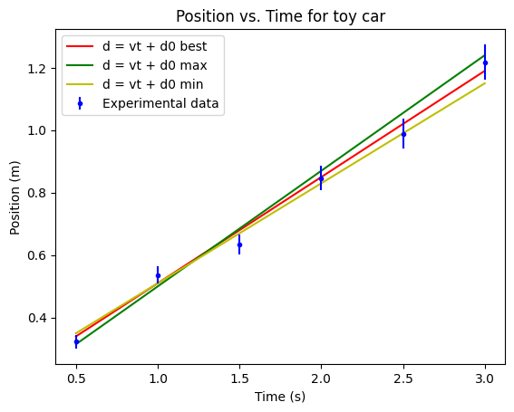

```python
# Run me to see all three models (best/max/min) on the same scatter plot

# Step 1: find the limits of the data:
xmin = np.min(tVec) # use the np.min function to find the smallest x value
xmax = np.max(tVec) # same for max
#print (xmin, xmax)  # uncomment to see what the limits are

# Step 2: generate a bunch of x points between xmin and xmax
xpoints = np.linspace(xmin, xmax, 200) # gives 200 evenly spaced points between xmin and xmax
#print(xpoints) # uncomment to see the x values that were generated.

# Step 3: calculate the model values:
best_slope = 0.34  # Estimate of the slope
best_intercept = 0.17  # Estimate of the intercept
best_ypoints = xpoints * best_slope + best_intercept # this calculates the yvalues at all 200 points.

max_slope = 0.37
min_intercept = 0.13
max_ypoints = xpoints * max_slope + min_intercept

min_slope = 0.32
max_intercept = 0.19
min_ypoints = xpoints * min_slope + max_intercept

# Uncertainties
um = (max_slope-min_slope)/2
ub = (max_intercept-min_intercept)/2
print("u[m] =",um,"m/s")
print("u[b] =",ub,"m")

# Step 4: plot the curve. We plot this as a red line "r-" :
plt.plot(xpoints, best_ypoints, "r-", label = "d = vt + d0 best")
plt.plot(xpoints, max_ypoints, "g-", label = "d = vt + d0 max")
plt.plot(xpoints, min_ypoints, "y-", label = "d = vt + d0 min")

# Plot the data:
plt.errorbar(tVec, dVec, udVec, fmt="bo", markersize=3, label="Experimental data")
plt.title("Position vs. Time for toy car")
plt.xlabel("Time (s)")
plt.ylabel("Position (m)")
plt.legend()
plt.show()
```

$$u\_m = (m_{\text{max}} - m_{\text{min}})/2 = (0.37-0.32)/2 = 0.025\text{ m/s}$$

and for the y-intercept:

$$u\_b = (0.19 - 0.13)/2 = 0.030\text{ m}$$

and an initial position ($b = d_0$) of:

$$d_0 \pm u\_d_0 = 0.170 \pm 0.030 \text{ m}$$

**Your turn #6:** Below is the experimental data for the position vs. time of a different toy car. Following the procedure as we covered in the above worked example (and in the tutorial), use the residual plot to determine the best fit model parameters and their uncertainties; from this conclude the initial position and speed of the toy car.

To review:

1. Start by plotting a scatterplot of the below data, with a linear model (with y-intercept) and a residuals plot. We provide the code for this below, with a poor starting guesses of $m = 0.7$ and $b = 0.2$.
2. Using the residuals plot, adjust the slope and the y-intercept values until you see no trend in the residuals. This will give you the best fit slope $m_{\text{best}}$ and y-intercept $b_{\text{best}}$.
3. Increase the slope/decrease the y-intercept to the extent possible where the model still fits the data reasonably well (as evaluated by the residuals). From this obtain $m_{\text{max}}$ and $b_{\text{min}}$. Analogously, obtain $m_{\text{min}}$ and $b_{\text{max}}$ by pushing the model parameters in the opposite direction.
4. From $m_{\text{max}}/m_{\text{min}}$ and $b_{\text{max}}/b_{\text{min}}$, calculate the uncertainties in $m$ and $b$.
5. The speed of the car can be identified as the slope of the distance vs. time graph, and the initial position can be identified as the y-intercept of the graph. Given this, report the speed and initial position of the toy car with uncertainty.

*Note: It is not necessary to copy and paste the same block of plotting code multiple times (this was done in the worked example above so that it is easier to follow); it suffices to have one single block of plotting code that you can run multiple times while changing the parameters inside.*

```python
# Run me to load our third data set
# Make sure to hit the "Generate Vectors" button!

de3 = data_entry2.sheet("lab06_prelab_data3.csv")
```

```
Sheet name: lab06_prelab_data3.csv
```

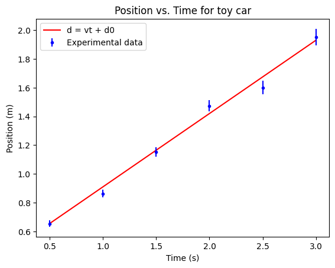

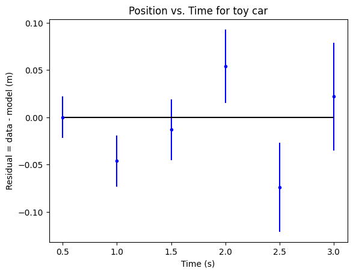

```python
# Data/Model Plot
# Step 1: find the limits of the data:
xmin = np.min(tVec) # use the np.min function to find the smallest x value
xmax = np.max(tVec) # same for max
#print (xmin, xmax)  # uncomment to see what the limits are

# Step 2: generate a bunch of x points between xmin and xmax
xpoints = np.linspace(xmin, xmax, 200) # gives 200 evenly spaced points between xmin and xmax
#print(xpoints) # uncomment to see the x values that were generated.

# Step 3: calculate the model values:
#
# Use the comments below to keep track of your best, max and min fit parameters
#
# m(best) = 0.51
# b(best) = 0.4
#
# m(max) = 0.55
# b(min) = 0.3
# Min
# m(min) = 0.51
# b(max) = 0.4
#

############## MODIFY THE MODEL PARAMETERS HERE #####################
slope = 0.51  # Estimate of the slope
intercept = 0.4  # Estimate of the intercept
#####################################################################
ypoints = xpoints * slope + intercept # this calculates the yvalues at all 200 points.

# Step 4: plot the curve. We plot this as a red line "r-" :
plt.plot(xpoints, ypoints, "r-", label = "d = vt + d0")

# Plot the data:
plt.errorbar(tVec, dVec, udVec, fmt="bo", markersize=3, label="Experimental data")
plt.title("Position vs. Time for toy car")
plt.xlabel("Time (s)")
plt.ylabel("Position (m)")
plt.legend()
plt.show()

# Residuals Plot
# Step 1: Calculate the model at each x-datapoint
ymodel = tVec * slope + intercept

# Step 2: Calcualte the residual vector
RVec = dVec - ymodel

# Step 3: Plot the residual vector against the x-data vector
plt.errorbar(tVec, RVec, udVec, fmt="bo", markersize = 3)

# Step 4: Add a R = 0 x-axis (horizontal line) to the plot
plt.hlines(y=0, xmin=xmin, xmax=xmax, color='k') # draw axis at y = 0.

# Add axis labels and title, and show the graph
plt.title("Position vs. Time for toy car")
plt.xlabel("Time (s)")
plt.ylabel("Residual = data - model (m)")
plt.show()
```

# Submit

Steps for submission:

1. Click: Run => Run_All_Cells
2. Read through the notebook to ensure all the cells executed correctly and without error.
3. File => Save_and_Export_Notebook_As->HTML
4. Inspect your downloaded html document
5. Upload the HTML document to the lab submission assignment on Canvas.

```python
display_sheets()
```

```
Sheet: de1   File: lab06_prelab_data1.csv
```

|  | x | u[x] | y1 | u[y1] | y2 | u[y2] | y3 | u[y3] |
| --- | --- | --- | --- | --- | --- | --- | --- | --- |
| Units | s | s | m | m | m | m | m | m |
| 0 | 0.2 | 0.01 | 1.20 | 0.01 | 3.42 | 0.01 | 3.2 | 0.01 |
| 1 | 1.1 | 0.01 | 2.12 | 0.01 | 5.19 | 0.01 | 4.11 | 0.01 |
| 2 | 1.9 | 0.01 | 2.89 | 0.01 | 6.8 | 0.01 | 4.95 | 0.01 |
| 3 | 3.1 | 0.01 | 4.11 | 0.01 | 9.17 | 0.01 | 6.19 | 0.01 |
| 4 | 4.0 | 0.01 | 5.0 | 0.01 | 11.0 | 0.01 | 7.17 | 0.01 |
| 5 | 4.9 | 0.01 | 5.93 | 0.01 | 12.81 | 0.01 | 8.13 | 0.01 |
| 6 | 5.8 | 0.01 | 6.79 | 0.01 | 14.58 | 0.01 | 9.14 | 0.01 |
| 7 | 6.9 | 0.01 | 7.88 | 0.01 | 16.8 | 0.01 | 10.38 | 0.01 |

```
Sheet: de2   File: lab06_prelab_data2.csv
```

|  | t | u[t] | d | u[d] |
| --- | --- | --- | --- | --- |
| Units | s | s | m | m |
| 0 | 0.500 | 0.001 | 0.323 | 0.022 |
| 1 | 1.000 | 0.001 | 0.537 | 0.027 |
| 2 | 1.500 | 0.001 | 0.634 | 0.032 |
| 3 | 2.000 | 0.001 | 0.847 | 0.039 |
| 4 | 2.500 | 0.001 | 0.989 | 0.047 |
| 5 | 3.000 | 0.001 | 1.218 | 0.057 |

```
Sheet: de3   File: lab06_prelab_data3.csv
```

|  | t | u[t] | d | u[d] |
| --- | --- | --- | --- | --- |
| Units | s | s | m | m |
| 0 | 0.500 | 0.001 | 0.655 | 0.022 |
| 1 | 1.000 | 0.001 | 0.864 | 0.027 |
| 2 | 1.500 | 0.001 | 1.152 | 0.032 |
| 3 | 2.000 | 0.001 | 1.474 | 0.039 |
| 4 | 2.500 | 0.001 | 1.601 | 0.047 |
| 5 | 3.000 | 0.001 | 1.952 | 0.057 |